# Assignment_2fml

Chhavi Bishnoi

2025-09-29

```r
library(caret)   # tools for splitting data, preprocessing, and running k-NN
library(dplyr)   # functions to clean, filter, and transform data smoothly
library(readr)   # reading CSV files
library(tibble)  # tibble() for neat one-row data frames
```

#Load the data into R

```r
#reading csv file
bank_reports <- read_csv("C:/Users/chhav/Downloads/UniversalBank.csv")
#make column name easy to interpret for R
names(bank_reports) <- make.names(names(bank_reports))
```

#Clean the data

```r
#Remove ID and ZIP.Code
bank_new_reports <- bank_reports %>%
  select(-ID, -ZIP.Code)

# Make the target variable a *factor* with labels "0" and "1"
bank_new_reports$Personal.Loan <- factor(bank_new_reports$Personal.Loan,
                                         levels = c(0,1), labels = c("0","1"))

#convert the Education into a factor with categories 1/2/3.
bank_new_reports$Education <- factor(bank_new_reports$Education, levels = c(1,2,3))
```

```r
#Turn categorical inputs into numbers (Dummies)

#Choose only INPUT columns (everything except the target Personal.Loan).
input_features <- setdiff(names(bank_new_reports), "Personal.Loan")

#convert categoricals to 0/1 columns (on TRAIN inputs only).
edu_dummy <- dummyVars(~ ., data = bank_new_reports[, input_features, drop = FALSE],
                 fullRank = FALSE)
```

Q-1 Training and validation

```r
#splitting data
set.seed(123)
Index_Train <- createDataPartition(bank_new_reports$Personal.Loan, p = 0.60, list = FALSE)
train_bank_new_reports <- bank_new_reports[Index_Train, ]     #training data(60%)
valid_bank_new_reports <- bank_new_reports[-Index_Train, ]    #validation dat(40%)
```

```r
# Apply that same dummy mapping to TRAIN and VALID inputs.
train_X <- predict(edu_dummy, newdata = train_bank_new_reports[, input_features, drop = FALSE]) %>% as.data.frame()
valid_X <- predict(edu_dummy, newdata = valid_bank_new_reports[, input_features, drop = FALSE]) %>% as.data.frame()

#Pull out the answer/label (0/1) for Train and Validation into separate vectors.
train_y <- train_bank_new_reports$Personal.Loan
valid_y <- valid_bank_new_reports$Personal.Loan
```

```r
#Put all numeric columns on the same scale (Standardize)

pp <- preProcess(train_X, method = c("center", "scale"))
train_X_norn <- predict(pp, train_X)
valid_X_norn <- predict(pp, valid_X)
pos_class <- if ("1" %in% levels(train_y)) "1" else levels(train_y)[2]

#train_X_norn and valid_X_norn are the scaled versions
```

Interpertation- firstly we divided the dataset in two parts training(60%) and validation(40%), later on personal loan(target variable) is being removed and the remaining dataset is normalized.

#Q-2 Classify the given customer with k=1

```r
# applying tibble as it creates a tiny table with exactly one row (one person).

new_cust <- tibble(
  Age = 40, Experience = 10, Income = 84, Family = 2, CCAvg = 2,
  Education = factor(2, levels = levels(train_bank_new_reports$Education)),
  Mortgage = 0, Securities.Account = 0, CD.Account = 0, Online = 1, CreditCard = 1
)

# In this, new customer’s categorical variables (like Education) into numeric dummy columns so they match the training set format.
new_customer_X  <- predict(edu_dummy, newdata = new_cust[, input_features, drop = FALSE]) %>% as.data.frame()
new_customer_norn <- predict(pp,  new_customer_X)

model_k1 <- knn3(x = train_X_norn, y = train_y, k = 1)   # build k-NN model (k=1)
prob_k1  <- predict(model_k1, new_customer_norn)       # get probability for new customer
pred_k1  <- ifelse(prob_k1[, pos_class] >= 0.5, "1", "0")  # classify: 1 if prob ≥ 0.5 else 0

#finding the class and probability of customer
cat(" New customer class with k=1:", pred_k1,
    " | P(class=1) =", round(prob_k1[, pos_class], 4), "\n")
```

```
##  New customer class with k=1: 0  | P(class=1) = 0
```

Interpretation- used k-NN with k = 1 to compute the probability for class “1” (loan accepted). The single nearest neighbor in the training set belongs to class 0, so P(class = 1) = 0.00. With the assignment rule (success class = “1”, cutoff = 0.5), the model classifies the customer as 0 (will not accept the loan),since customer belongs to class 0 it means that the customer will not accept the loan.

#Q-3 Find a “good k” by trying many k’s and picking highest validation accuracy

```r
set.seed(123)
k_value <- seq(1, 31, by = 2)
ary   <- numeric(length(k_value))

for (i in seq_along(k_value)) {
  k_now <- k_value[i]
  knn_model  <- knn3(x = train_X_norn, y = train_y, k = k_now)
  prob_valid <- predict(knn_model, valid_X_norn)
  class_pred <- factor(ifelse(prob_valid[, pos_class] >= 0.5, "1", "0"), levels = c("0", "1"))
  ary[i] <- mean(class_pred == valid_y)
}

acc_df   <- data.frame(k = k_value, accuracy = ary)
best_acc <- max(acc_df$accuracy)
best_k   <- max(acc_df$k[acc_df$accuracy == best_acc])
cat(" Best k:", best_k, " | Validation accuracy =", round(best_acc, 4), "\n")
```

```
##  Best k: 1  | Validation accuracy = 0.9645
```

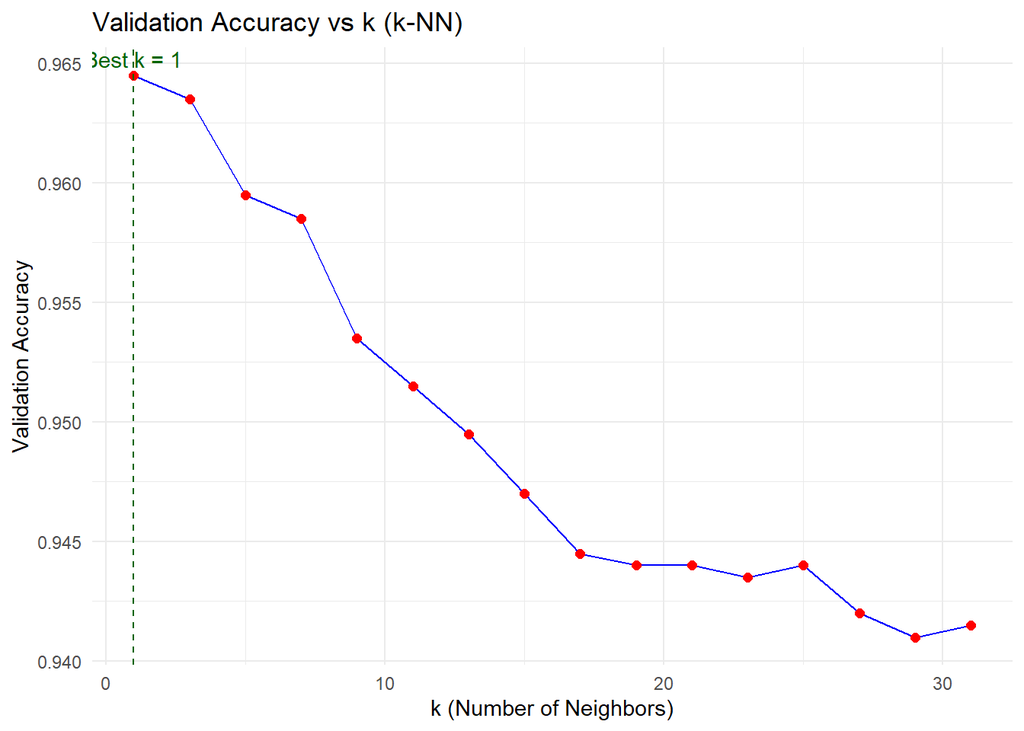

```r
#plotting graph
ggplot(acc_df, aes(x = k, y = accuracy)) +
  geom_line(color = "blue") +
  geom_point(color = "red", size = 2) +
  geom_vline(xintercept = best_k, linetype = "dashed", color = "darkgreen") +
  annotate("text", x = best_k, y = best_acc,
           label = paste0("Best k = ", best_k),
           vjust = -0.5, color = "darkgreen") +
  labs(title = "Validation Accuracy vs k (k-NN)",
       x = "k (Number of Neighbors)",
       y = "Validation Accuracy") +
  theme_minimal()
```

Interpretation- finding the best optimal value of k by running it in a loop from 1 to 31 which returned the value of k = 1, it implies that the maximum accuracy is attained when the value of k is 1.

#Q-4 — Confusion matrix on validation using best k

```r
best_model <- knn3(x = train_X_norn, y = train_y, k = best_k)
best_prob  <- predict(best_model, valid_X_norn)
best_pred  <- factor(ifelse(best_prob[, pos_class] >= 0.5, "1", "0"), levels = c("0","1"))

cm_valid <- confusionMatrix(best_pred, valid_y, positive = "1")
cat(" Confusion Matrix (Validation, best k):\n"); print(cm_valid)
```

```
##  Confusion Matrix (Validation, best k):
```

```
## Confusion Matrix and Statistics
##
##           Reference
## Prediction    0    1
##          0 1793   56
##          1   15  136
##
##                Accuracy : 0.9645
##                  95% CI : (0.9554, 0.9722)
##     No Information Rate : 0.904
##     P-Value [Acc > NIR] : < 2.2e-16
##
##                   Kappa : 0.7739
##
##  Mcnemar's Test P-Value : 2.063e-06
##
##             Sensitivity : 0.7083
##             Specificity : 0.9917
##          Pos Pred Value : 0.9007
##          Neg Pred Value : 0.9697
##              Prevalence : 0.0960
##          Detection Rate : 0.0680
##    Detection Prevalence : 0.0755
##       Balanced Accuracy : 0.8500
##
##        'Positive' Class : 1
##
```

Interpretation- Building best-k model, predict on validation set, and use confusion matrix to evaluate accuracy, sensitivity, specificity.

#Q-5 Classify the same customer using best k

```r
best_prob_new <- predict(best_model, new_customer_norn)
best_pred_new <- ifelse(best_prob_new[, pos_class] >= 0.5, "1", "0")
cat(" New customer class with best k (k =", best_k, "):", best_pred_new,
    " | P(class=1) =", round(best_prob_new[, pos_class], 4), "\n")
```

```
##  New customer class with best k (k = 1 ): 0  | P(class=1) = 0
```

Interpretation- Classifying the new customer again, this time using the best k and it returned 0 which means the new customer didnot accept the loan.

#Q-6 Repartition into Train/Valid/Test = 50% / 30% / 20% and compare

```r
set.seed(456)

# dividing dataset into testing (20%)
idx_test <- createDataPartition(bank_new_reports$Personal.Loan, p = 0.20, list = FALSE)
test_raw <- bank_new_reports[idx_test, ]
remain   <- bank_new_reports[-idx_test, ]  # 80% remains

# partitioning the remaining data into training(50%) and validation(30%)
idx_train2 <- createDataPartition(remain$Personal.Loan, p = 0.625, list = FALSE) # 0.625 = 50/80
train2_raw <- remain[idx_train2, ]   # ~50%
valid2_raw <- remain[-idx_train2, ]  # ~30%

# Dummies on TRAIN2 ONLY (predictors only)
predictor_names2 <- setdiff(names(train2_raw), "Personal.Loan")
edu_dummy2 <- dummyVars(~ ., data = train2_raw[, predictor_names2, drop = FALSE], fullRank = FALSE)

train2_X <- predict(edu_dummy2, train2_raw[, predictor_names2, drop = FALSE]) %>% as.data.frame()
valid2_X <- predict(edu_dummy2, valid2_raw[, predictor_names2, drop = FALSE]) %>% as.data.frame()
test2_X  <- predict(edu_dummy2, test_raw[,  predictor_names2, drop = FALSE]) %>% as.data.frame()

train2_y <- train2_raw$Personal.Loan
valid2_y <- valid2_raw$Personal.Loan
test2_y  <- test_raw$Personal.Loan

# Scale using TRAIN2 only
pp2 <- preProcess(train2_X, method = c("center", "scale"))
train2_Xs <- predict(pp2, train2_X)
valid2_Xs <- predict(pp2, valid2_X)
test2_Xs  <- predict(pp2, test2_X)

# Predict with previously chosen best_k
model2 <- knn3(x = train2_Xs, y = train2_y, k = best_k)

pred_train2 <- factor(ifelse(predict(model2, train2_Xs)[, "1"] >= 0.5, "1", "0"), levels = c("0","1"))
pred_valid2 <- factor(ifelse(predict(model2, valid2_Xs)[, "1"] >= 0.5, "1", "0"), levels = c("0","1"))
pred_test2  <- factor(ifelse(predict(model2,  test2_Xs)[,  "1"] >= 0.5, "1", "0"), levels = c("0","1"))

cm_train2 <- confusionMatrix(pred_train2, train2_y, positive = "1")
cm_valid2 <- confusionMatrix(pred_valid2, valid2_y, positive = "1")
cm_test2  <- confusionMatrix(pred_test2,  test2_y,  positive = "1")

cat(" Confusion Matrix — TRAIN (50%):\n");      print(cm_train2)
```

```
##  Confusion Matrix — TRAIN (50%):
```

```
## Confusion Matrix and Statistics
##
##           Reference
## Prediction    0    1
##          0 2260    0
##          1    0  240
##
##                Accuracy : 1
##                  95% CI : (0.9985, 1)
##     No Information Rate : 0.904
##     P-Value [Acc > NIR] : < 2.2e-16
##
##                   Kappa : 1
##
##  Mcnemar's Test P-Value : NA
##
##             Sensitivity : 1.000
##             Specificity : 1.000
##          Pos Pred Value : 1.000
##          Neg Pred Value : 1.000
##              Prevalence : 0.096
##          Detection Rate : 0.096
##    Detection Prevalence : 0.096
##       Balanced Accuracy : 1.000
##
##        'Positive' Class : 1
##
```

```r
cat(" Confusion Matrix — VALIDATION (30%):\n"); print(cm_valid2)
```

```
##  Confusion Matrix — VALIDATION (30%):
```

```
## Confusion Matrix and Statistics
##
##           Reference
## Prediction    0    1
##          0 1326   39
##          1   30  105
##
##                Accuracy : 0.954
##                  95% CI : (0.9421, 0.964)
##     No Information Rate : 0.904
##     P-Value [Acc > NIR] : 3.461e-13
##
##                   Kappa : 0.7274
##
##  Mcnemar's Test P-Value : 0.3355
##
##             Sensitivity : 0.7292
##             Specificity : 0.9779
##          Pos Pred Value : 0.7778
##          Neg Pred Value : 0.9714
##              Prevalence : 0.0960
##          Detection Rate : 0.0700
##    Detection Prevalence : 0.0900
##       Balanced Accuracy : 0.8535
##
##        'Positive' Class : 1
##
```

```r
cat(" Confusion Matrix — TEST (20%):\n");       print(cm_test2)
```

```
##  Confusion Matrix — TEST (20%):
```

```
## Confusion Matrix and Statistics
##
##           Reference
## Prediction   0   1
##          0 891  27
##          1  13  69
##
##                Accuracy : 0.96
##                  95% CI : (0.9459, 0.9713)
##     No Information Rate : 0.904
##     P-Value [Acc > NIR] : 1.476e-11
##
##                   Kappa : 0.7535
##
##  Mcnemar's Test P-Value : 0.03983
##
##             Sensitivity : 0.7188
##             Specificity : 0.9856
##          Pos Pred Value : 0.8415
##          Neg Pred Value : 0.9706
##              Prevalence : 0.0960
##          Detection Rate : 0.0690
##    Detection Prevalence : 0.0820
##       Balanced Accuracy : 0.8522
##
##        'Positive' Class : 1
##
```

Interpretation-

Training data : The training matrix shows perfect classification: all 2,260 “No Loan” customers and all 240 “Loan” customers were correctly classified. Accuracy, Sensitivity, and Specificity are all 100%, which indicates the model fits the training data extremely well. However, such perfection often suggests the possibility of overfitting, since the model may have memorized the training set.

Validation data: Accuracy is 95.4%, slightly lower than training but still strong. Sensitivity = 72.9%: the model correctly identifies about 73% of actual loan acceptors, meaning it misses around 27% of positives. Specificity = 97.8%: the model is excellent at recognizing customers who won’t accept the loan. Balanced Accuracy (85.3%) confirms the model does better on negatives than positives. This demonstrates that while the model generalizes reasonably, it is biased towards predicting “No Loan”, which is expected given the class imbalance (only ~9.6% positives).

Test data: Accuracy remains high at 96%, consistent with the validation set. Sensitivity = 71.9%: very similar to validation, showing stable performance in detecting loan acceptors. Specificity = 98.6%: again very strong, meaning almost all non-loan customers are predicted correctly. Positive Predictive Value (84.1%) is better here, showing that when the model predicts “Loan,” it is more likely to be correct compared to validation. Balanced Accuracy (85.2%) mirrors the validation results, reinforcing that the model is robust and not overly tuned to a single dataset.